# Individual3

Julia Lundstrum

2/15/2021

# Individual 3 - Julia Lundstrum

```r
choco <- read.csv("https://raw.githubusercontent.com/xdaiISU/ds202materials/master/hwlabs/data/choco.csv")
```

## Searching for the Best Chocolates

### How are the ratings distributed?

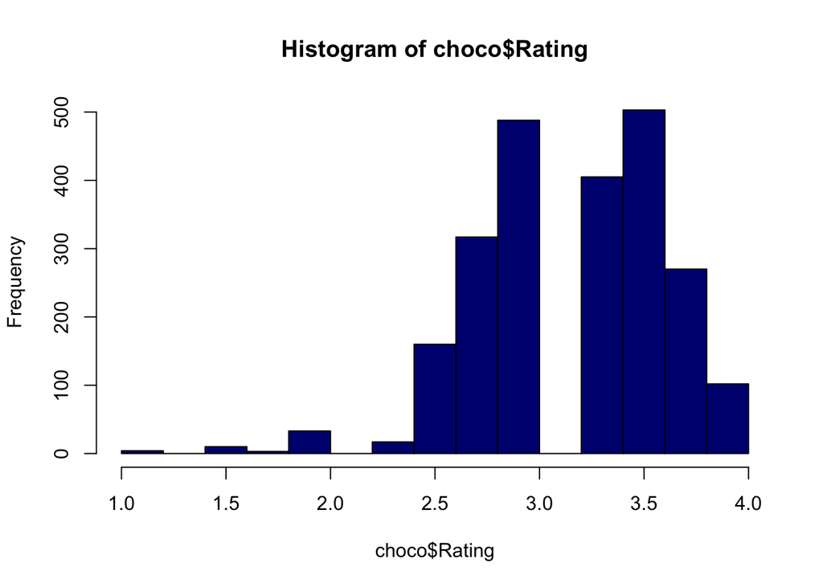

```r
hist(choco$Rating, col = "navy")
```

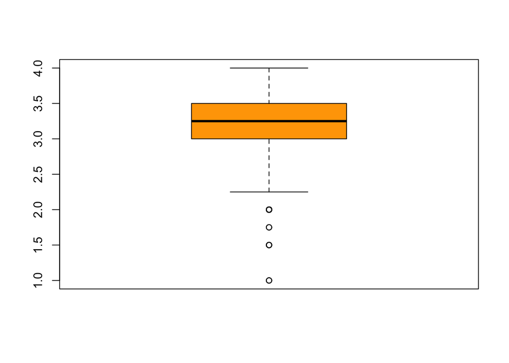

```r
boxplot(choco$Rating, col = "orange")
```

### How does the number of ratings depend on the location of the company?

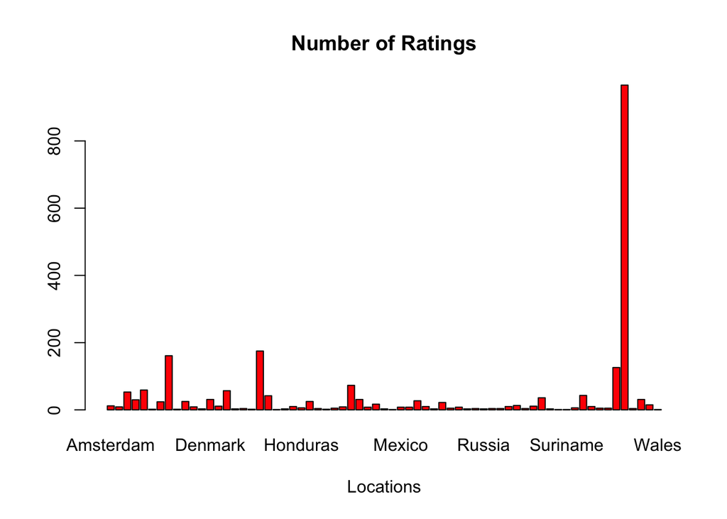

```r
freq <- table(choco$Location)
barplot(freq, main = "Number of Ratings", xlab = "Locations", col = "red")
```

### Do ratings depend on the cacao percentage of a chocolate bar?

```r
library(ggplot2)
new <- choco[, c('Cocoa_Percent','Rating')]
corr <- round(cor(new),2)
corr
```

```
##               Cocoa_Percent Rating
## Cocoa_Percent          1.00  -0.15
## Rating                -0.15   1.00
```

```r
summary(new)
```

```
##  Cocoa_Percent        Rating
##  Min.   : 42.00   Min.   :1.000
##  1st Qu.: 70.00   1st Qu.:3.000
##  Median : 70.00   Median :3.250
##  Mean   : 71.65   Mean   :3.184
##  3rd Qu.: 75.00   3rd Qu.:3.500
##  Max.   :100.00   Max.   :4.000
```

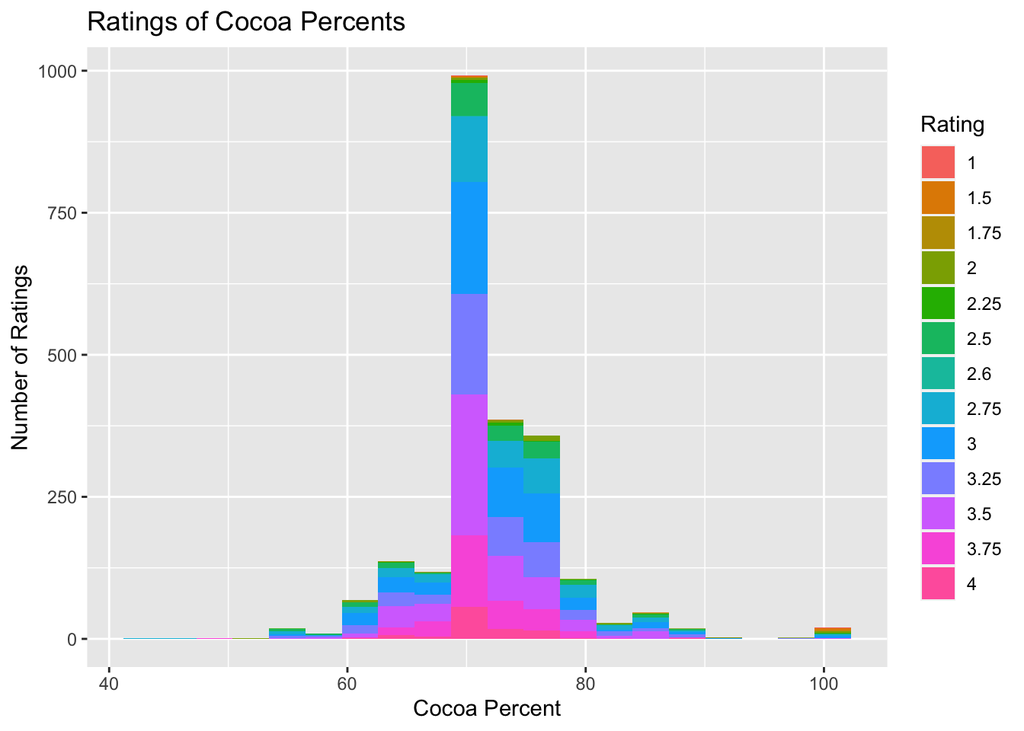

```r
newdf <- choco
newdf$Rating=factor(newdf$Rating)
ggplot(newdf, aes(Cocoa_Percent, fill = Rating)) + geom_histogram(bins = 20) + ggtitle("Ratings of Cocoa Percents") + ylab("Number of Ratings") + xlab("Cocoa Percent")
```

### How do different bean origins compare in terms of the flavor of chocolates? Are beans from some places better than the other? Create both numerical and graphical summaries, and explain

```r
new2 <- choco[, c('Bean_Origin','Rating')]
aggregate(new2[, 2], list(new2$Bean_Origin), mean)
```

```
##                  Group.1        x
## 1              Australia 3.250000
## 2                 Belize 3.227612
## 3                  blend 3.000000
## 4                  Blend 3.034768
## 5                Bolivia 3.180556
## 6                 Bolvia 3.250000
## 7                 Brazil 3.253333
## 8                  Burma 3.000000
## 9               Cameroon 3.083333
## 10              Colombia 3.204545
## 11                 Congo 3.318182
## 12            Costa Rica 3.151163
## 13                  Cuba 3.291667
## 14    Dominican Republic 3.201942
```

[output cut: 49 more lines]

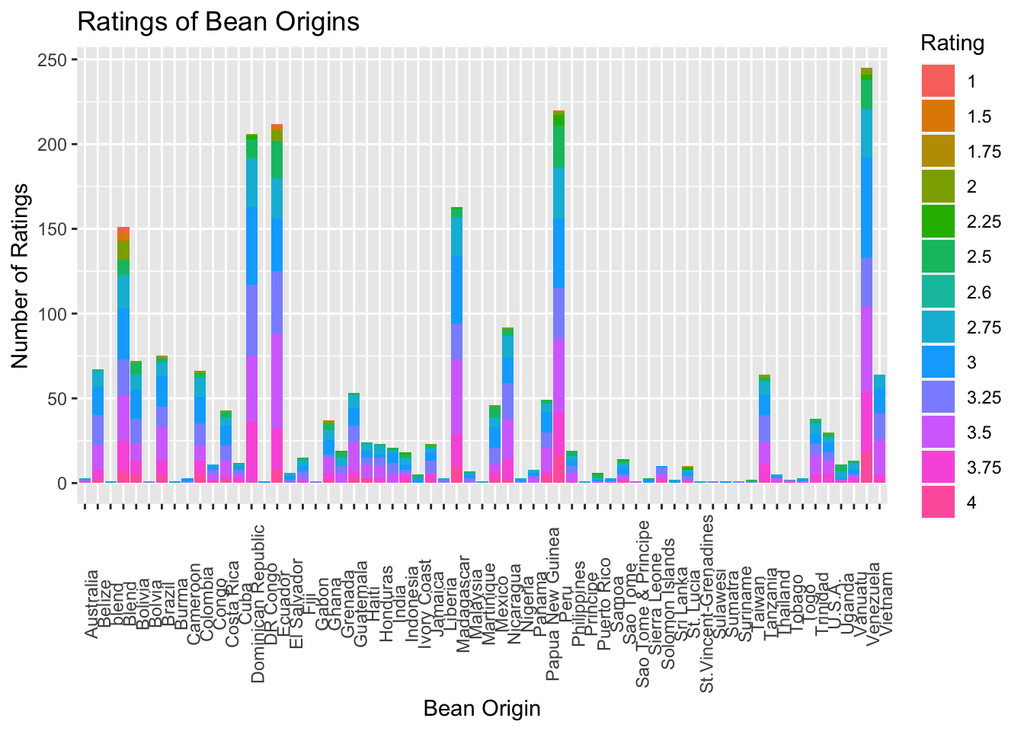

```r
ggplot(newdf, aes(Bean_Origin, fill = Rating)) + geom_bar() + ggtitle("Ratings of Bean Origins") + ylab("Number of Ratings") + xlab("Bean Origin") + theme(axis.text.x = element_text(angle = 90))
```

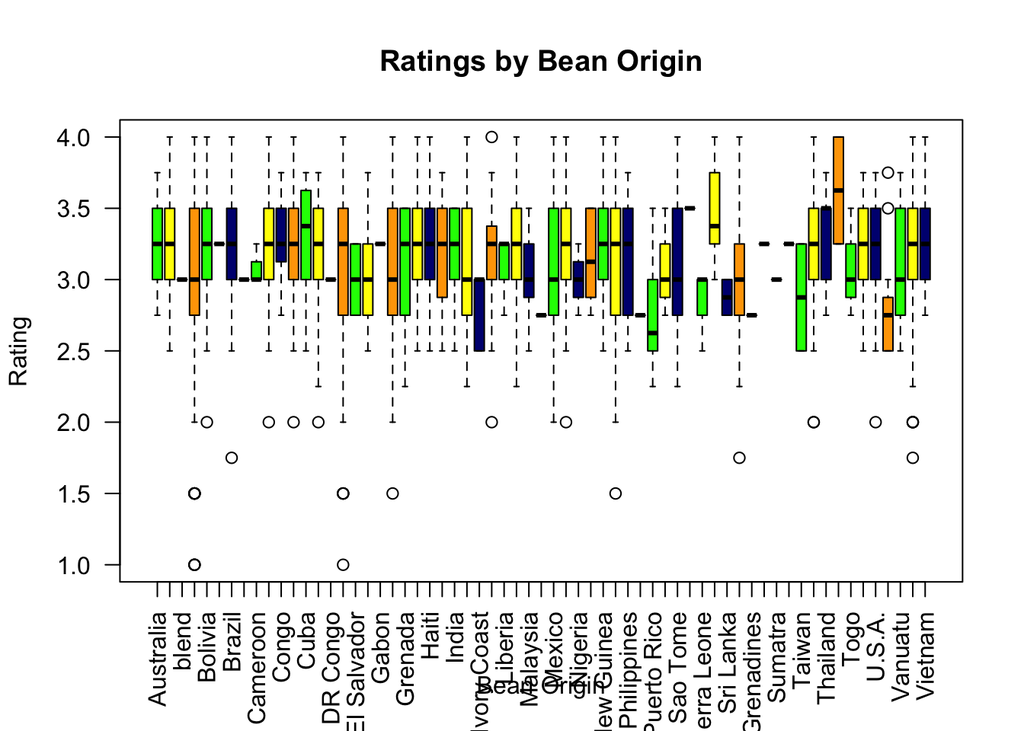

```r
boxplot(choco$Rating ~ choco$Bean_Origin, col=c("green","yellow","navy","orange"), main = "Ratings by Bean Origin", xlab = "Bean Origin", ylab = "Rating", las = 2)
```

#### There does not appear to be a significant relationship between bean origin and the rating of the chocolate. The mean rating for the different bean origins are about the same. There are a few that are a bit higher, but the sample size is not large enough to determine if that was just by chance.

### Brainstorm two analyses you would like to perform (with your teammates). Describe in plain language what comparisons are you making. Create suitable numerical and graphical summaries for your analyses. Describe the results.

```r
new3 <- choco[, c('Date','Rating')]
corr2 <- round(cor(new3),2)
corr2
```

```
##        Date Rating
## Date   1.00   0.09
## Rating 0.09   1.00
```

```r
summary(new3)
```

```
##       Date          Rating
##  Min.   :2006   Min.   :1.000
##  1st Qu.:2011   1st Qu.:3.000
##  Median :2014   Median :3.250
##  Mean   :2014   Mean   :3.184
##  3rd Qu.:2016   3rd Qu.:3.500
##  Max.   :2020   Max.   :4.000
```

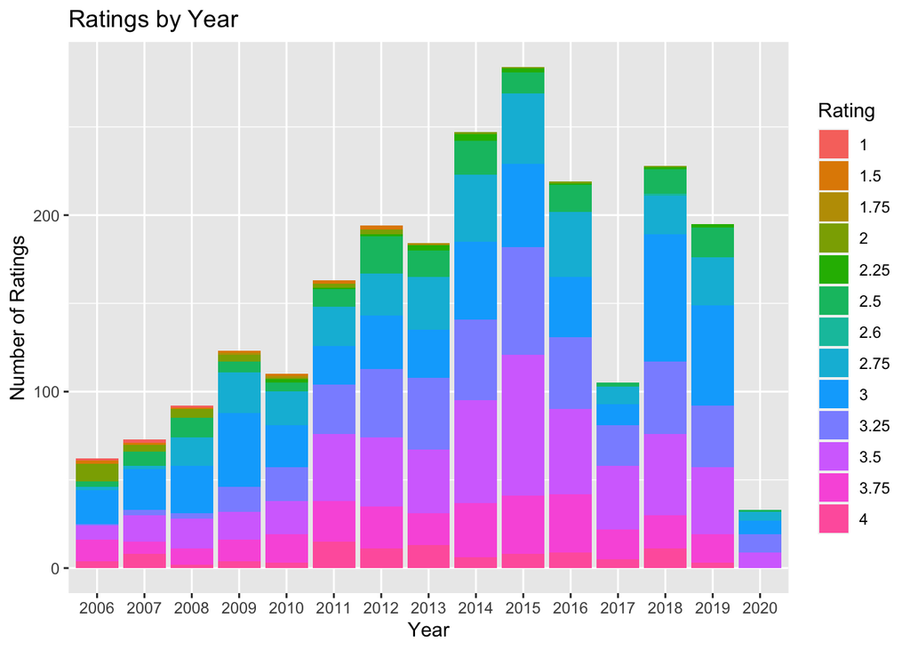

```r
newdf2 <- choco
newdf2$Rating=factor(newdf2$Rating)
newdf2$Date=factor(newdf2$Date)
ggplot(newdf2, aes(Date, fill = Rating)) + geom_bar() + ggtitle("Ratings by Year") + ylab("Number of Ratings") + xlab("Year")
```

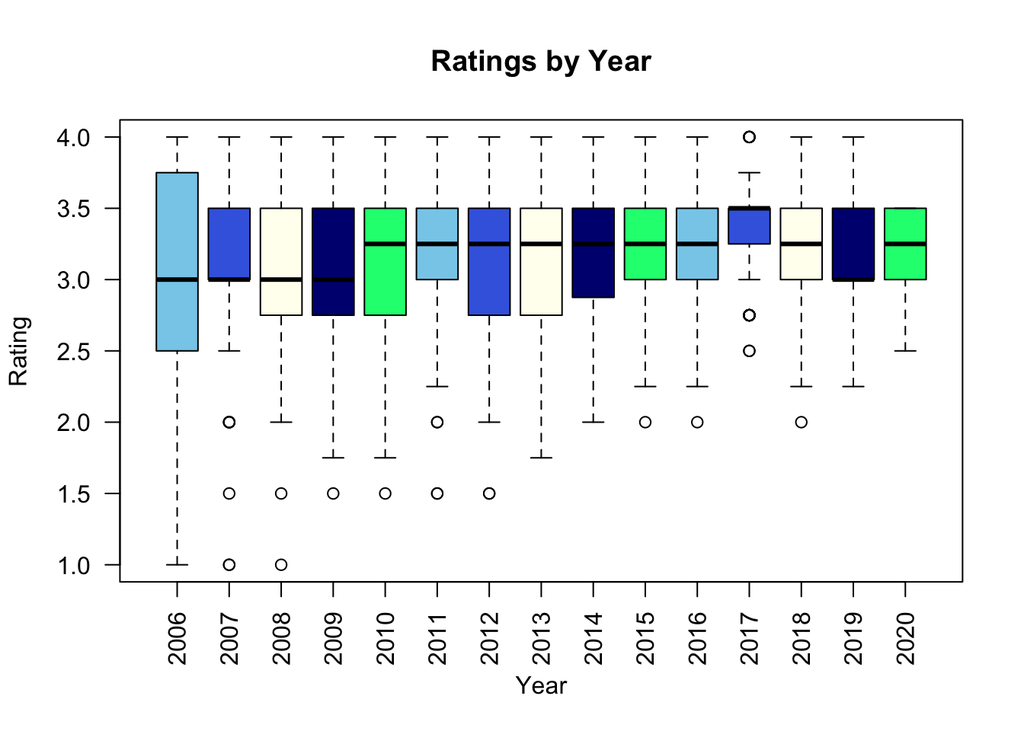

```r
boxplot(choco$Rating ~ choco$Date, col=c("skyblue","royalblue","ivory","navy","springgreen"), main = "Ratings by Year", xlab = "Year", ylab = "Rating", las = 2)
```

#### I decided to analyze the relationship between ratings and what year they were rated. There is not a correlation between the year rated and rating received. I used a stacked bar graph and box plots to analyze the data.